# HELMi metaData overview

# Goals and objectives:

This documents aims to provide an overview on the HELMi contextual dataset extracted from the families questionnaires.

The following aspects are considered:

- Types and sparcity of the contextual dataset
- Family compliance

# Dataset description:

**infants questionnaires:**

- A_background
- F1_NutritionMotorDev_year1_version1 or F1_NutritionMotorDev_year1_version2
- F2_NutritionMotorDev_year2_version1 or F2_NutritionMotorDev_year2_version2

**infants frequency questionnaires:**

- E_Previous3Months
- C_4to6months
- D_7to12months
- B_0to3months

**parents questionnaires:**

- G_ParentF_FoodFrequency
- G_ParentM_FoodFrequency
- G_MotherDepression
- G0_MotherStress and G2_MotherStress

**Other questionnaires:**

- H_HouseCollection

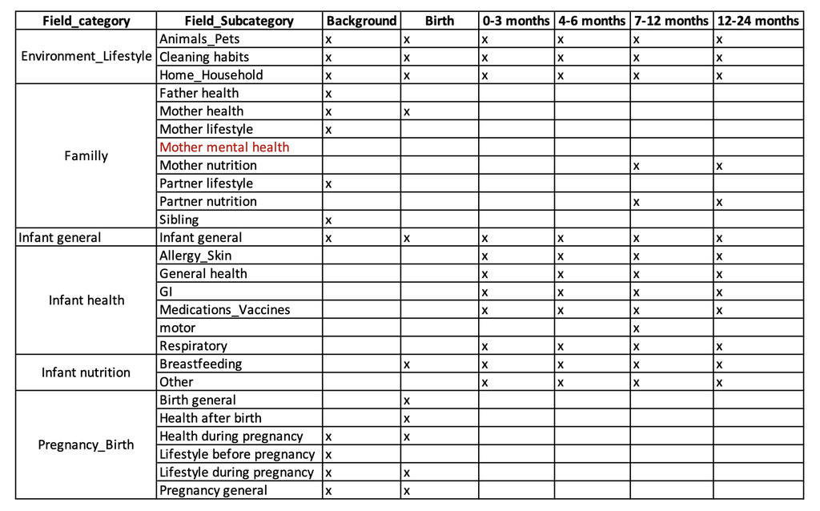

# General overview

## Types of Metadata

Overview of the type of metadata in each questionnaire. Note that “mult_categorical” corresponds to multiple choice categories.

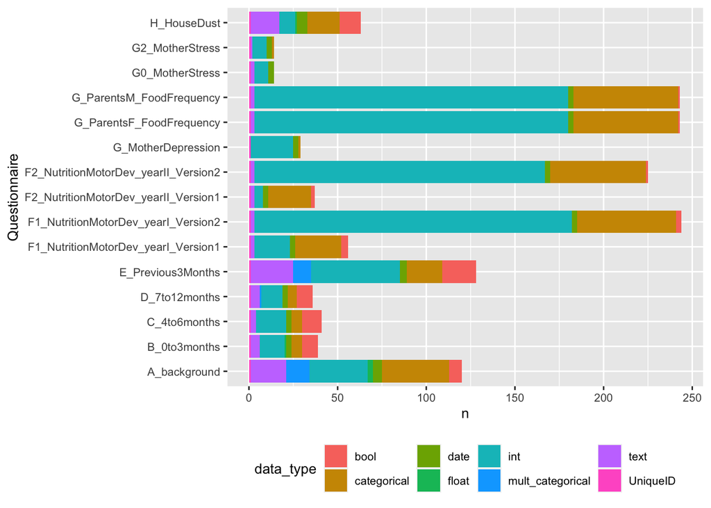

## Usability of Metadata

Overview of the direct usability of the contextual dataset. “TO CURATE” indicates fields where a manual extraction of the data would be vaulable. “TO CORRECT” indicates fields where a conversion or type correction would be valuable. “CORRECTED” indicates a field where the data was converted or corrected in a major way (this do not include the simple category translation).

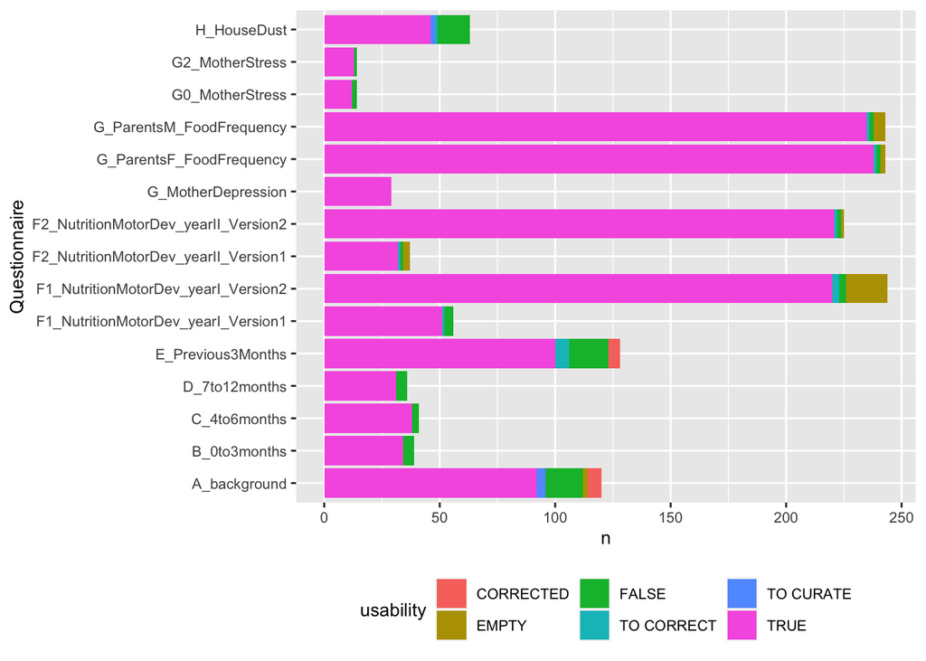

# Questionnaire sparcity

Looking at the number of NA per column in each questionnaire

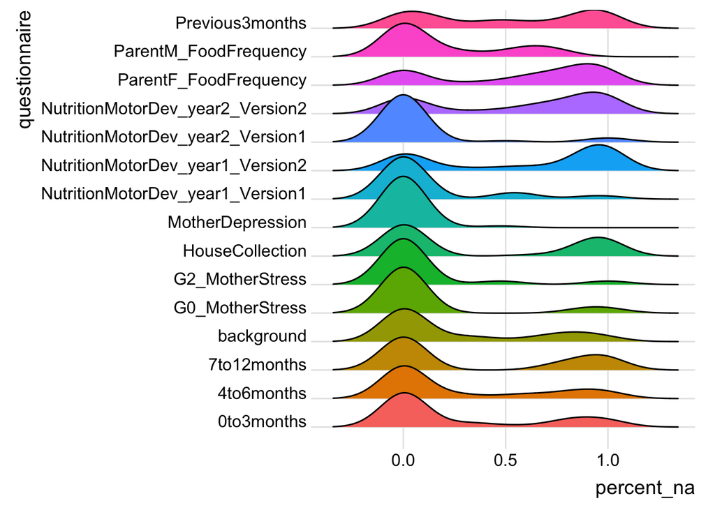

# Familly compliance

## Compliance overview

number of famillies answering the questionnaire at least once

| questionnaire | nb of famillies |
| --- | --- |
| A_background | 1055 |
| B_0to3months | 1056 |
| C_4to6months | 1011 |
| D_7to12months | 1002 |
| E_Previous3Months | 1012 |
| F1_NutritionMotorDev_year1_Version1 | 532 |
| F1_NutritionMotorDev_year1_Version2 | 431 |
| F2_NutritionMotorDev_year2_Version1 | 6 |
| F2_NutritionMotorDev_year2_Version2 | 901 |
| G_MotherDepression | 683 |
| G_ParentF_FoodFrequency | 745 |
| G_ParentM_FoodFrequency | 923 |
| G0_MotherStress | 1076 |
| G2_MotherStress | 689 |
| H_HouseCollection | 268 |

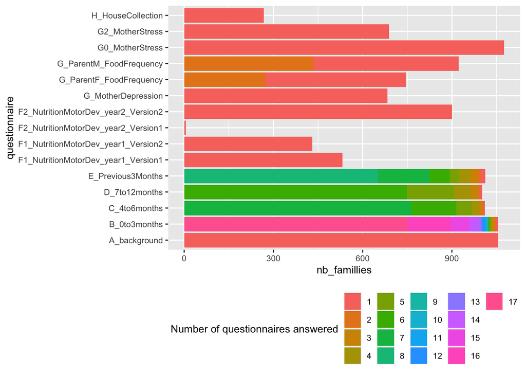

## Family compliance in questionnaires

overview per familly: Famillies answering all the regular questionnaires

| measures | nb families |
| --- | --- |
| all infants | 891 |
| all infants frequency | 426 |
| all parents | 379 |
| all major questionnaires | 121 |
| all major infants and frequency | 422 |
| all major infants and most frequency | 767 |

## Family answer levels in questionnaires

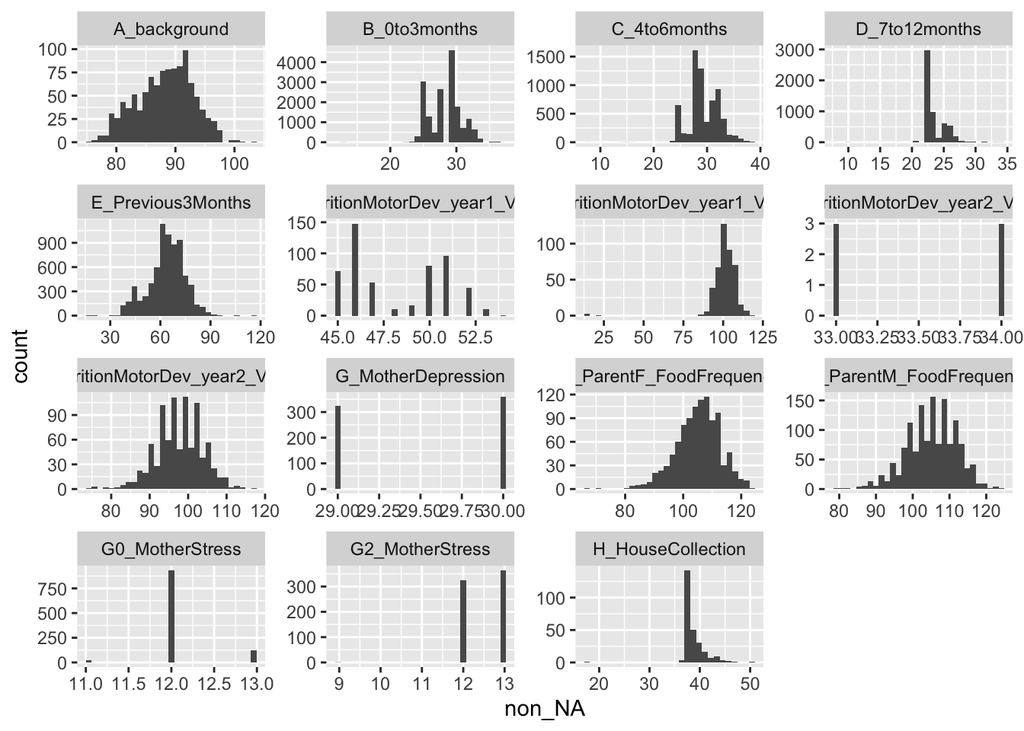